# Some information for getting started R

yhyim

2017 2 25

### airquality 데이터를 이용해 데이터 탐색에 유용한 R 함수 살펴보기

1. `dim` - 데이터의 레코드(R 용어로 observation) 수와 컬럼(R 용어로 variable) 수를 반환

```r
dim(airquality)
```

```
## [1] 153   6
```

2. `head` - 데이터의 상위 6개 레코드 반환

```r
head(airquality)
```

```
##   Ozone Solar.R Wind Temp Month Day
## 1    41     190  7.4   67     5   1
## 2    36     118  8.0   72     5   2
## 3    12     149 12.6   74     5   3
## 4    18     313 11.5   62     5   4
## 5    NA      NA 14.3   56     5   5
## 6    28      NA 14.9   66     5   6
```

- `head` 함수 인자값으로 숫자를 지정하면 그 숫자만큼의 레코드를 반환

```r
head(airquality, 10)
```

```
##    Ozone Solar.R Wind Temp Month Day
## 1     41     190  7.4   67     5   1
## 2     36     118  8.0   72     5   2
## 3     12     149 12.6   74     5   3
## 4     18     313 11.5   62     5   4
## 5     NA      NA 14.3   56     5   5
## 6     28      NA 14.9   66     5   6
## 7     23     299  8.6   65     5   7
## 8     19      99 13.8   59     5   8
## 9      8      19 20.1   61     5   9
## 10    NA     194  8.6   69     5  10
```

3. `tail` - `head` 함수와 유사하지만 하위의 6개 레코드를 반환

```r
tail(airquality)
```

```
##     Ozone Solar.R Wind Temp Month Day
## 148    14      20 16.6   63     9  25
## 149    30     193  6.9   70     9  26
## 150    NA     145 13.2   77     9  27
## 151    14     191 14.3   75     9  28
## 152    18     131  8.0   76     9  29
## 153    20     223 11.5   68     9  30
```

4. `table` - 데이터 컬럼의 데이터별 빈도수를 반환

```r
table(airquality$Ozone)
```

```
##
##   1   4   6   7   8   9  10  11  12  13  14  16  18  19  20  21  22  23
##   1   1   1   3   1   3   1   3   2   4   4   4   4   1   4   4   1   6
##  24  27  28  29  30  31  32  34  35  36  37  39  40  41  44  45  46  47
##   2   1   3   1   2   1   3   1   2   2   2   2   1   1   3   2   1   1
##  48  49  50  52  59  61  63  64  65  66  71  73  76  77  78  79  80  82
##   1   1   1   1   2   1   1   2   1   1   1   2   1   1   2   1   1   1
##  84  85  89  91  96  97 108 110 115 118 122 135 168
##   1   2   1   1   1   2   1   1   1   1   1   1   1
```

- R 내장 loop function 중에 하나인 `sapply` (simple apply 의 약자)와 결합하면 모든 컬럼의 데이터별 빈도수를 한 번에 확인 가능

```r
sapply(airquality, table)
```

```
## $Ozone
##
##   1   4   6   7   8   9  10  11  12  13  14  16  18  19  20  21  22  23
##   1   1   1   3   1   3   1   3   2   4   4   4   4   1   4   4   1   6
##  24  27  28  29  30  31  32  34  35  36  37  39  40  41  44  45  46  47
##   2   1   3   1   2   1   3   1   2   2   2   2   1   1   3   2   1   1
##  48  49  50  52  59  61  63  64  65  66  71  73  76  77  78  79  80  82
##   1   1   1   1   2   1   1   2   1   1   1   2   1   1   2   1   1   1
##  84  85  89  91  96  97 108 110 115 118 122 135 168
##   1   2   1   1   1   2   1   1   1   1   1   1   1
##
## $Solar.R
##
##   7   8  13  14  19  20  24  25  27  31  36  37  44  47  48  49  51  59
##   1   1   1   1   1   1   2   1   1   1   1   1   1   1   1   1   1   1
##  64  65  66  71  77  78  81  82  83  91  92  95  98  99 101 112 115 118
##   1   1   1   1   1   1   1   1   1   1   2   1   1   1   1   1   1   1
## 120 127 131 135 137 138 139 145 148 149 150 153 157 167 175 183 186 187
##   1   2   1   1   2   1   2   1   1   1   1   1   1   1   3   1   1   1
## 188 189 190 191 192 193 194 197 201 203 207 212 213 215 220 222 223 224
##   1   1   2   2   1   1   1   1   1   1   1   1   1   1   3   1   3   1
## 225 229 230 236 237 238 242 244 248 250 252 253 254 255 256 258 259 260
##   1   1   1   2   2   4   1   1   1   2   2   1   1   2   1   1   4   1
## 264 266 267 269 272 273 274 275 276 279 284 285 286 287 290 291 294 295
##   2   1   1   1   1   2   2   1   1   1   1   1   1   1   1   2   1   1
## 299 307 313 314 320 322 323 332 334
##   1   1   1   1   1   2   1   1   1
##
## $Wind
##
##  1.7  2.3  2.8  3.4    4  4.1  4.6  5.1  5.7  6.3  6.9  7.4    8  8.6  9.2
##    1    1    1    1    1    1    4    3    3    8    9   10   11    8    8
##  9.7 10.3 10.9 11.5   12 12.6 13.2 13.8 14.3 14.9 15.5 16.1 16.6 18.4 20.1
##   11   11    8   15    4    3    2    5    6    8    3    1    3    1    1
## 20.7
##    1
##
## $Temp
##
## 56 57 58 59 61 62 63 64 65 66 67 68 69 70 71 72 73 74 75 76 77 78 79 80 81
##  1  3  2  2  3  2  1  2  2  3  4  4  3  1  3  3  5  4  4  9  7  6  6  5 11
## 82 83 84 85 86 87 88 89 90 91 92 93 94 96 97
##  9  4  5  5  7  5  3  2  3  2  5  3  2  1  1
##
## $Month
##
##  5  6  7  8  9
## 31 30 31 31 30
##
## $Day
##
##  1  2  3  4  5  6  7  8  9 10 11 12 13 14 15 16 17 18 19 20 21 22 23 24 25
##  5  5  5  5  5  5  5  5  5  5  5  5  5  5  5  5  5  5  5  5  5  5  5  5  5
## 26 27 28 29 30 31
##  5  5  5  5  5  3
```

4. `str` - 데이터 탐색에 가장 유용한 함수로써 데이터의 레코드, 컬럼수, 각 컬럼별 테이터 타입 및 데이터 샘플 정보를 반환함. structure 의 약자

```r
str(airquality)
```

```
## 'data.frame':    153 obs. of  6 variables:
##  $ Ozone  : int  41 36 12 18 NA 28 23 19 8 NA ...
##  $ Solar.R: int  190 118 149 313 NA NA 299 99 19 194 ...
##  $ Wind   : num  7.4 8 12.6 11.5 14.3 14.9 8.6 13.8 20.1 8.6 ...
##  $ Temp   : int  67 72 74 62 56 66 65 59 61 69 ...
##  $ Month  : int  5 5 5 5 5 5 5 5 5 5 ...
##  $ Day    : int  1 2 3 4 5 6 7 8 9 10 ...
```

5. `summary` - 데이터의 모든 컬럼에 대한 평균, 중앙값, 사분위값, 최대값, 최소값을 반환함

```r
summary(airquality)
```

```
##      Ozone           Solar.R           Wind             Temp
##  Min.   :  1.00   Min.   :  7.0   Min.   : 1.700   Min.   :56.00
##  1st Qu.: 18.00   1st Qu.:115.8   1st Qu.: 7.400   1st Qu.:72.00
##  Median : 31.50   Median :205.0   Median : 9.700   Median :79.00
##  Mean   : 42.13   Mean   :185.9   Mean   : 9.958   Mean   :77.88
##  3rd Qu.: 63.25   3rd Qu.:258.8   3rd Qu.:11.500   3rd Qu.:85.00
##  Max.   :168.00   Max.   :334.0   Max.   :20.700   Max.   :97.00
##  NA's   :37       NA's   :7
##      Month            Day
##  Min.   :5.000   Min.   : 1.0
##  1st Qu.:6.000   1st Qu.: 8.0
##  Median :7.000   Median :16.0
##  Mean   :6.993   Mean   :15.8
##  3rd Qu.:8.000   3rd Qu.:23.0
##  Max.   :9.000   Max.   :31.0
##
```

### R의 plot 기능을 이용한 데이터 시각화 맛보기

1. **히스토그램** - 하나의 값에 대한 빈도 분포를 막대그래프로 표현

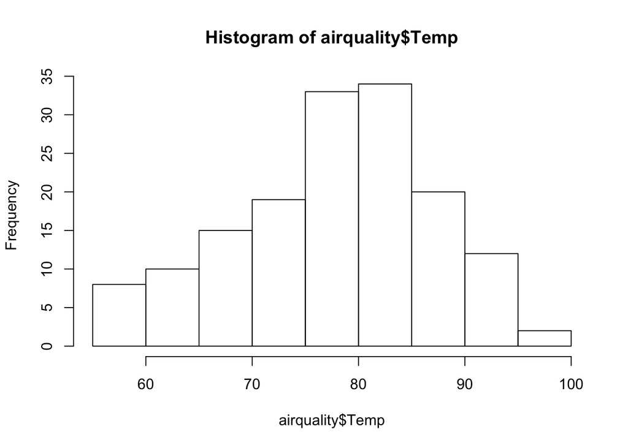

```r
hist(airquality$Temp)
```

2. **스캐터플롯** - 두 개의 값에 대한 관계를 점 또는 막대로 표현

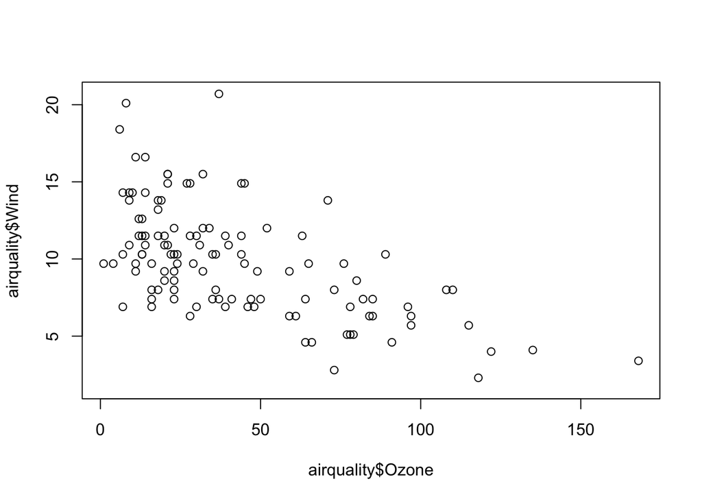

```r
plot(airquality$Ozone, airquality$Wind)
```

- 스캐터플롯에 옵션을 적용하여 플롯을 꾸밀 수 있음

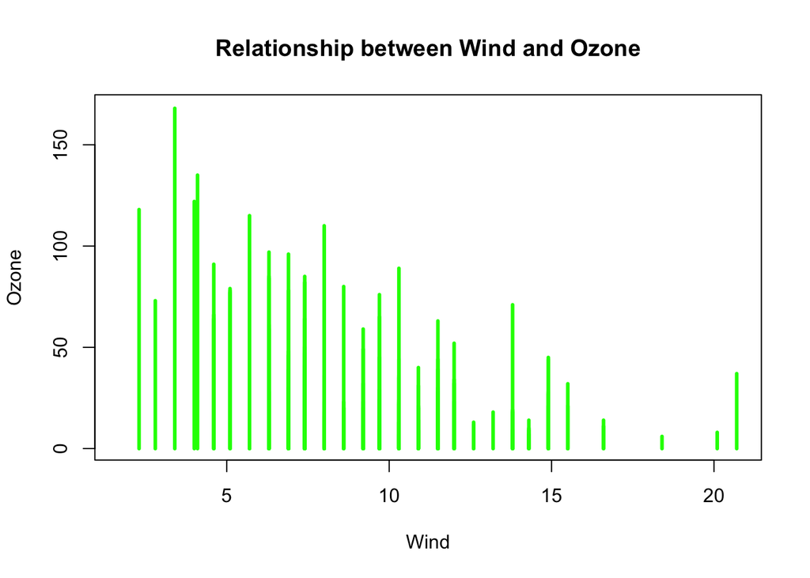

```r
plot(airquality$Wind, airquality$Ozone, xlab = "Wind", ylab = "Ozone", main = "Relationship between Wind and Ozone", type = "h", lwd = 3, col = "green")
```